# task7_3

Manvydas Sokolovas

20 April 2016

**Užkraunamas “fpp” paketas. Toliau bus naudojami duomenys iš jo:**

```r
library("fpp")
```

### 3 užduotis:

**For the data set bricksq:**

**(a)Split the data into two parts using:**

```r
bricks1 <- window(bricksq, end=1987.99)
bricks2 <- window(bricksq, start=1988)
```

**(b)Check that your data have been split appropriately by producing the following plot:**

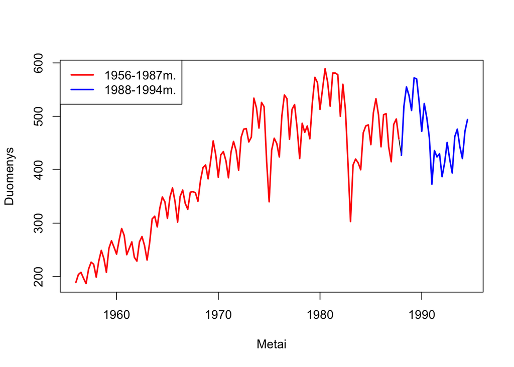

```r
plot(bricksq, xlab="Metai", ylab="Duomenys")
legend("topleft", legend=c("1956-1987m.", "1988-1994m."), col=c("red","blue"), lwd=2, cex=1)
lines(bricks1, col="red", lwd=2)
lines(bricks2, col="blue", lwd=2)
```

**(c)Calculate forecasts using each of the four benchmark methods applied to bricks1.**

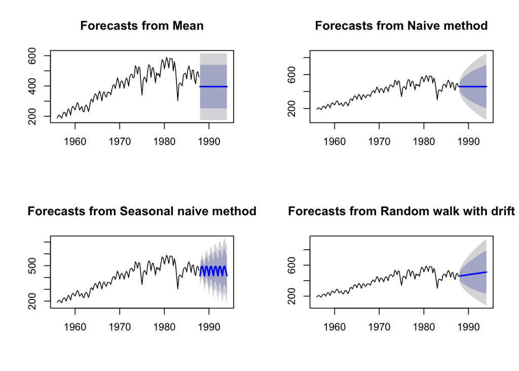

```r
par(mfrow = c(2,2))
avg <- meanf(bricks1, h =25)             #prognozė pagal duomenų vidurkį
plot(avg)

naive <- naive(bricks1, h=25)            #prognozė pagal paskutinę duomenų reikšmę
plot(naive)

season <- snaive(bricks1, h=25)          #prognozė pagal sezoniškumą
plot(season)

drift <- rwf(bricks1, drift=TRUE, h=25)  #prognozė pagal paskutinę reikšmę bei prideda vidutinį svyravimą praeityje
plot(drift)
```

- Galima spėti, jog geriausiai prognozuoja trečiasis grafikas (Forecasts from Seasonal naive method), nes duomenys yra sezoniški.

**(d)Compare the accuracy of your forecasts against the actual values stored in bricks2.**

```r
accuracy(avg,bricks2)
```

```
##                    ME      RMSE      MAE       MPE     MAPE     MASE
## Training set  0.00000 110.49649 95.04700 -9.952875 28.71184 2.756919
## Test set     72.02531  91.88928 74.75844 14.138924 14.86229 2.168432
##                   ACF1 Theil's U
## Training set 0.9195361        NA
## Test set     0.6818170  1.843487
```

```r
accuracy(naive,bricks2)
```

```
##                    ME     RMSE      MAE       MPE      MAPE      MASE
## Training set  2.11811 40.15629 31.85039 0.1878701  8.173353 0.9238477
## Test set     10.08000 57.94480 48.24000 0.7097401 10.140512 1.3992421
##                     ACF1 Theil's U
## Training set -0.07205841        NA
## Test set      0.68181699  1.194809
```

```r
accuracy(season,bricks2)
```

```
##                    ME     RMSE      MAE       MPE     MAPE    MASE
## Training set 8.508065 48.60531 34.47581 2.0011274 8.666006 1.00000
## Test set     6.760000 50.67662 42.76000 0.4059943 8.959088 1.24029
##                   ACF1 Theil's U
## Training set 0.7955186        NA
## Test set     0.9065816  1.067661
```

```r
accuracy(drift,bricks2)
```

```
##                         ME     RMSE     MAE        MPE      MAPE      MASE
## Training set  2.237990e-14 40.10039 31.8393 -0.3959664  8.187045 0.9235258
## Test set     -1.745543e+01 69.92107 63.2463 -5.4985437 13.914527 1.8345125
##                     ACF1 Theil's U
## Training set -0.07205841        NA
## Test set      0.76646079  1.551223
```

**(e) Which method does best? Why?**

- Iš (d) dalies galima matyti, jog “Seasonal naive” prognozės Training set ir Test set reikšmės poromis mažiausiai skiriasi palyginus su kitais prognozavimo metodais, taigi galima teigti, jog “Seasonal naive” metodas geriau prognozuoja nei kiti.

Vienoje ploštumoje išbrėžiami tikrųjų duomenų bei visų prognozių grafikai:

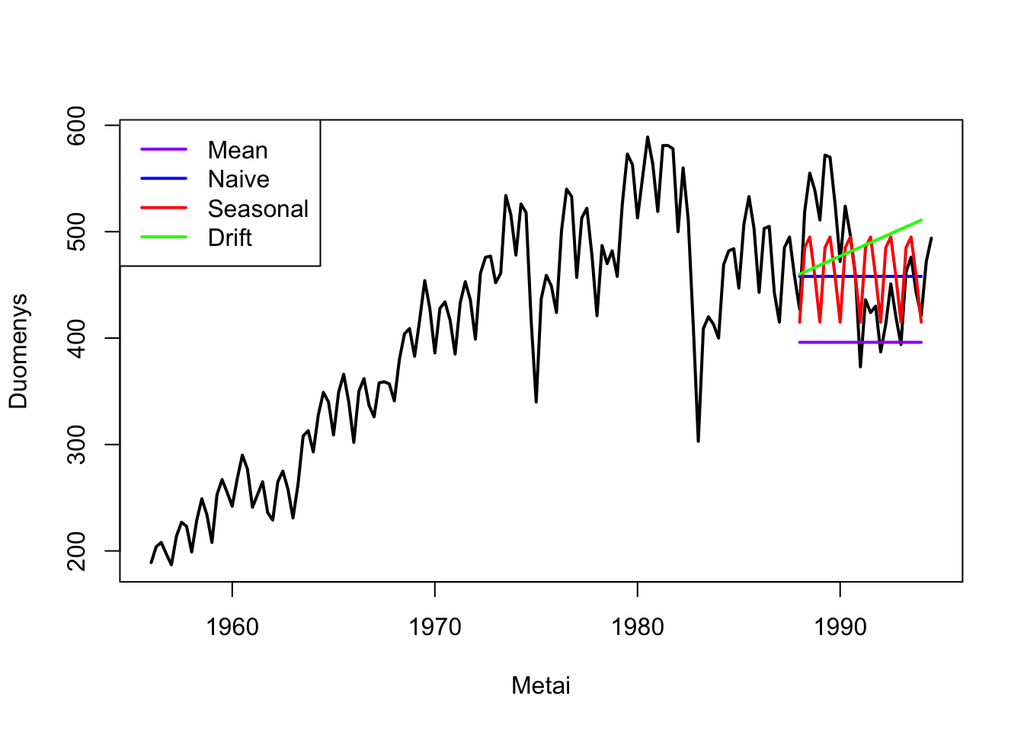

```r
plot(bricksq, xlab="Metai", ylab="Duomenys", lwd=2)
lines(avg$mean,col="purple",lwd=2)
lines(naive$mean, col="blue", lwd=2)
lines(season$mean, col="red", lwd=2)
lines(drift$mean, col="green", lwd=2)
legend("topleft", legend=c("Mean", "Naive", "Seasonal", "Drift"), col=c("purple", "blue", "red", "green"), lwd=2, cex=1)
```

- Iš šio grafiko taip pat galima matyti, jog “Seasonal” metodas prognozuoja tiksliausiai. Tai yra jo reikšmės panašiausios į turimų duomenų.

**(f) For the best method, compute the residuals and plot them. For example:**

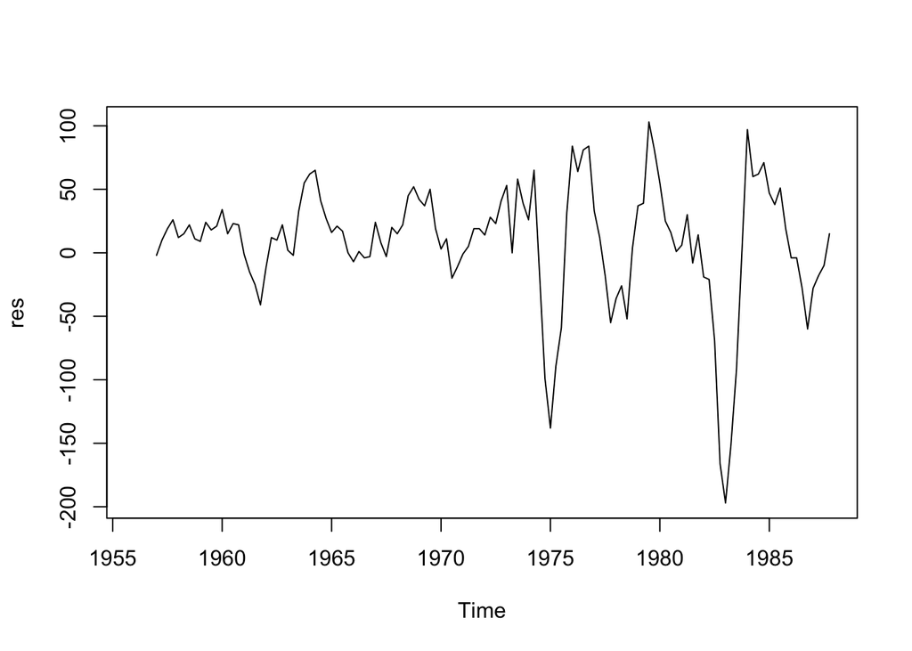

```r
res <- residuals(season)
plot(res)
```

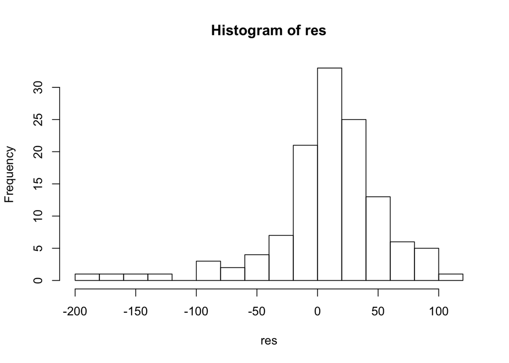

```r
hist(res, breaks="FD")
```

- Iš grafiko galima matyti, jog liekanos nėra pasiskirsčiusios ties nuliu bei reikšmės vis didėja. Tačiau iš histogramos panašu, jog liekanos pasiskirste pagal normalųjį skirstinį ir reikšmės labiausiai susitelke ties nuliu.

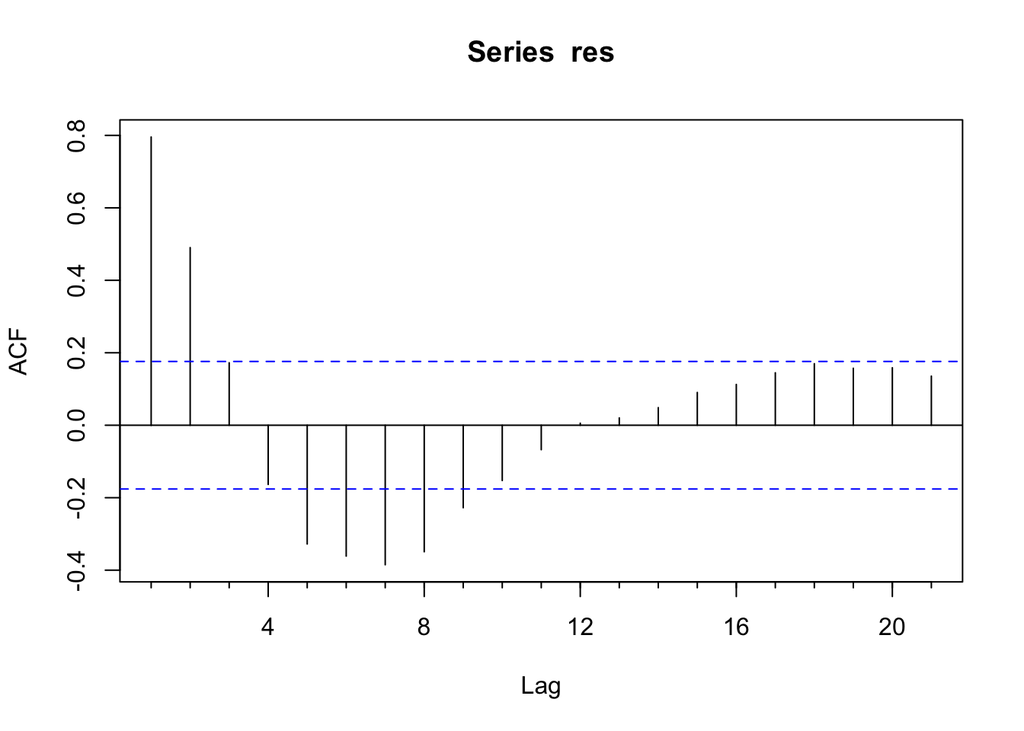

```r
Acf(res)
```

- ACF rodo reikšmingą autokoreliaciją prie 1, 2, 5, 6, 7, 8 ir 9 lagų (kur stulpeliai kerta mėlyną puktyrinę liniją).

Atliksime Ljung-Box testą, su H0 hipoteze, kad duomenų liekanos yra baltasis triukšmas ir alternatyva, kad nėra.

```r
Box.test(res, fitdf=0, type="Lj")
```

```
##
##  Box-Ljung test
##
## data:  res
## X-squared = 80.387, df = 1, p-value < 2.2e-16
```

- p-value < 0.05, H0 atmetame. Liekanos nėra baltasis triukšmas (liekanos koreliuoja).